# Untitled

## Part Zero

Completed

```r
library(dplyr)
library(tidyverse)
```

```r
library(ggplot2)
#install.packages('readXl')
data1 <- readxl::read_xls("C:\\Users\\samue\\OneDrive\\Documents\\GSS.xls")
data1
```

```
## # A tibble: 64,816 x 10
##    `Gss year for this ~ `General happine~ `Political party af~ `Region of inter~
##                   <dbl> <chr>             <chr>                <chr>
##  1                 1972 Not too happy     Ind,near dem         E. nor. central
##  2                 1972 Not too happy     Not str democrat     E. nor. central
##  3                 1972 Pretty happy      Independent          E. nor. central
##  4                 1972 Not too happy     Not str democrat     E. nor. central
##  5                 1972 Pretty happy      Strong democrat      E. nor. central
##  6                 1972 Pretty happy      Ind,near dem         E. nor. central
##  7                 1972 Not too happy     Ind,near dem         E. nor. central
##  8                 1972 Not too happy     Ind,near dem         E. nor. central
##  9                 1972 Pretty happy      Strong democrat      W. sou. central
## 10                 1972 Pretty happy      Strong democrat      W. sou. central
## # ... with 64,806 more rows, and 6 more variables: Race of respondent <chr>,
## #   Respondents sex <chr>, Highest year of school completed <chr>,
## #   Marital status <chr>, Respondent id number <dbl>,
## #   Ballot used for interview <chr>
```

## Question 1

Find the average years of education for the respondents with each marital status. Arrange your output in a meaningful order and print. Describe any patterns you find.

Patterns: After getting the data and arranging it in the descending order, it was interesting to see that the population that selected to not answer had the highest education status. After that there is a group of 3 within 0.4 years, which would be Never married, Divorced, or Married. The lowest mean Education are people that answered Widowed. The differenct between the averages is 4.3.

```r
data1 %>%
  mutate(`Highest year of school completed` = as.numeric(`Highest year of school completed`)) %>%
  group_by(`Marital status`) %>%
  summarize(meanEdu = mean(`Highest year of school completed`, na.rm=TRUE)) %>%
  arrange(desc(meanEdu))
```

```
## # A tibble: 7 x 2
##   `Marital status` meanEdu
##   <chr>              <dbl>
## 1 No answer           15.5
## 2 Never married       13.4
## 3 Divorced            13.1
## 4 Married             13.0
## 5 Separated           11.9
## 6 Widowed             11.2
## 7 <NA>               NaN
```

## Question 2

Create a single data frame containing records for the better educated respondents with each marital status. A “better educated” respondent is someone who has strictly more years of education than the average among those with the same marital status. Print the structure of the data frame.

```r
data3  <- filter(data1, `Marital status` == 'No answer' & `Highest year of school completed` > 15.5 | `Marital status` == 'Never married' & `Highest year of school completed` > 13.4 | `Marital status` == 'Divorced' & `Highest year of school completed` > 13.1 | `Marital status` == 'Married' & `Highest year of school completed` > 13.0 | `Marital status` == 'Separated' & `Highest year of school completed` > 11.9 | `Marital status` == 'Widowed' & `Highest year of school completed` > 11.2)
```

## Question 3

How is the happiness of a respondent related to his/her marriage status? Define that a person is happy if the response to question is “Very happy” or “Pretty happy”.

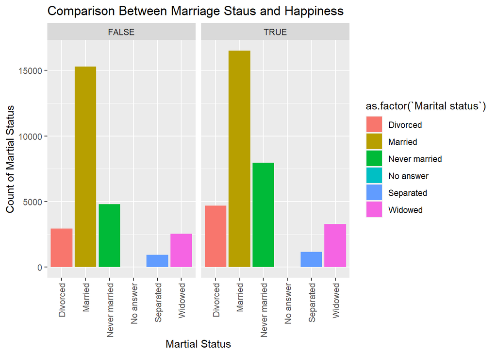

```r
data4 <-data1 %>%
  filter(`General happiness` %in% c('Very happy', 'Pretty happy', 'Not too happy')) %>%
  mutate(HappyOrNot = (`General happiness` %in% c('very happy', 'Pretty happy'))) %>%
  select(`General happiness`, `Marital status` , HappyOrNot)


p <- ggplot(data = data4, aes(x = `Marital status`, fill = as.factor(`Marital status`)))+geom_bar()+facet_grid(. ~HappyOrNot)
p + theme(axis.text.x = element_text(angle = 90, vjust = 0.5, hjust = 1))+ xlab("Martial Status")+ylab("Count of Martial Status")+ggtitle("Comparison Between Marriage Staus and Happiness")
```

```r
table(data4$HappyOrNot)
```

```
##
## FALSE  TRUE
## 26491 33563
```

```r
happy <- (33563/(26491+33563))*100
happy
```

```
## [1] 55.88803
```

```r
unhappy <- 100 - happy
unhappy
```

```
## [1] 44.11197
```